# Final Project

Ian Pfeffer

May 21, 2019

## Background

"The 27 Club" is an unofficial nomenclature for a group of popular celebrities whom all died at the age of 27. Notable "members" include Jim Morrison of The Doors fame and Jimi Hendrix.

In the past 20 years, there have been no entrants into the 27 club. Therefore, for the purpose of this projects, we will consider anyone who died at an age within the 5 year range of 25-30 years old.

## Problem Statement

Is being inducted into the 27 club a statistically significant event? How many entrants would one expect per year going forward? Given the way they died, could you predict if they would be an entrant

## Input Data Set

https://www.kaggle.com/hugodarwood/celebrity-deaths It is a collection of celebrity deaths from Wikipedia over the 10-year interval of 2006-2016. -Sample Size=21458 -Blank cause of death is considered NA or "unknown"

First, we downloaded the data set and scraped it using read.csv and converted it to a dataframe

```r
library(tidyverse) # loading code goes here
setwd("C:/Users/Ian Pfeffer/Documents/CMSC320/Data")

celeb_deaths <- read.csv("celebrity_deaths.csv")[c("age","birth_year","cause_of_death","death_year","name")] %>%
  mutate(cause_of_death = na_if(cause_of_death, ""))

celeb_deaths %>%
  slice(1:10)
```

```
##    age birth_year                                cause_of_death death_year
## 1   85       1921                                natural causes       2006
## 2   49       1957                                      murdered       2006
## 3   64       1942                           Alzheimer's disease       2006
## 4   86       1920                           Alzheimer's disease       2006
## 5   82       1924                                        cancer       2006
## 6   52       1954                                        stroke       2006
## 7   31       1975                   probably pulmonary embolism       2006
## 8   31       1975  from injuries sustained in a biking accident       2006
## 9   55       1951                                          <NA>       2006
## 10  70       1936                                   lung cancer       2006
##                   name
## 1           Frank Cary
## 2         Bryan Harvey
## 3        Paul Lindblad
## 4    Charles O. Porter
## 5           Ofelia Fox
## 6    Sir William Skate
## 7     G塘bor Zavadszky
## 8  Jos泰 Luis S塘nchez
## 9         Gordon Smith
## 10         Don Stewart
```

| Name | Type | Description |
| --- | --- | --- |
| Age | Discrete Numerical | Age which celebrity died |
| birth_year | Discrete Numerical | Year celebrity was born |
| cause_of_death | Unordered Categorical | String identifying cause of death of celebrity |
| death_year | Discrete Numerical | Year celebrity died |
| name | Unordered Categorical | String identifying name of celebrity |

## Distribution of ages

First, let抯 look at the distribution of the number of deaths per age. We do this by grouping by age, summarizing how many rows there are per each age, and then graphing it with a bar graph.

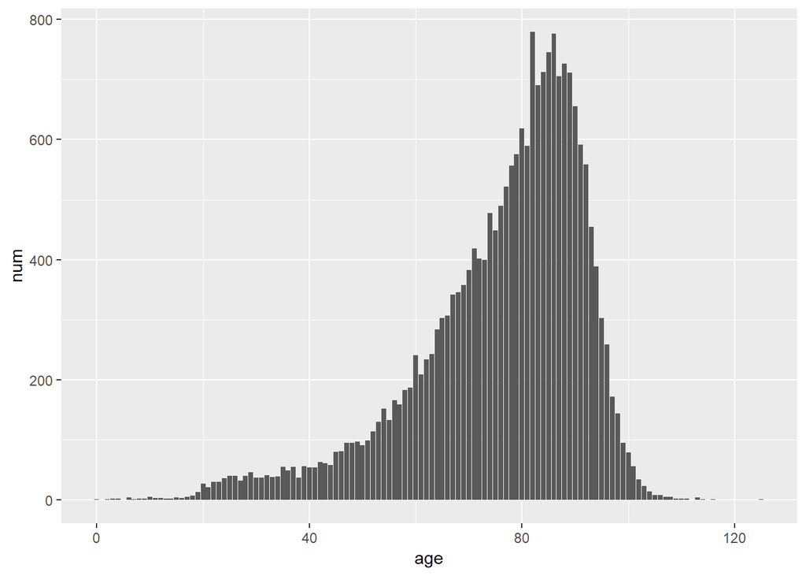

```r
library(dplyr)
library(tidyr)
celeb_deaths %>%
  group_by(age) %>% #group_by groups per age
  summarize(num = n()) %>% #summarize will gives us a summary of the data as a dataframe, and n() just means count the rows
  ggplot(mapping = aes(x=age, y=num)) + #create a plot with age on the x axis and the count on the y axis
    geom_bar(stat = "identity") #make the plot a bar graph,=
```

The graph centers around 80 years old, which is expected considering the average age of death in the modern world sits around the same. There is a bit of a left-leaning skew, meaning the possibilities of younger deaths does not decrease as drastically the further away from the center we get, which is not necessarily good news for the exclusitivity of the 27 club.

*Is there a statistically significant difference between celebrity deaths in that age group and normal ages of death distributions of the US population?*

According to the CDC, in the year 2007, about 42,500 people out of about 2,423,700 people died in the raneg we are interested in.

This data comes from: https://www.cdc.gov/nchs/data/dvs/MortFinal2007_Worktable23f.pdf

We will use this proportion as the True proportion of deaths for this range, and we will call this $p_0$. It's variance will be $\frac{p_0 * (1-p_0)}{n}$, where $n$ is the 2,423,700 people who died.

```r
n <- 2423712
p_0 <- 42572/n
var_p_0 <- 1/n * p_0 * (1-p_0)
```

We want to use this as our baseline in order to test whether our celebrity data shows anything suspicious. Our alternative hypothesis is the number of deaths in our range divided by the total amount of deaths.

```r
#nrow is similar to summarize(n()), but gives back a number rather than a dataframe.
#filter is used to grab only the data with ages between 25 and 30, inclusive.
#This way we can get a correct proportion for our statistic by dividing the number of rows that meet our condition by the total
p_A <- nrow(filter(filter(celeb_deaths, age >=25), age <= 30))/nrow(celeb_deaths)
```

This proportion is approximately .01095 or 1% of all celebrity deaths from 2006 to 2016. We will say that this is statistically significant if the probability that we get this proportion given $p_0$ is a correct estimate is less than .05 or 5%. Otherwise, we cannot say anything about whether this "exclusive" club is actually that exclusive.

```r
pnorm(p_A, mean = p_0, sd = sqrt(var_p_0))
```

```
## [1] 0
```

By all means this is statistically significant. According to this hypothesis test, there is by no means that a proportion of people who died in this range could be considered normal. Therefore, it is not without reason to suggest the infamous 27 club is special.

## Does Cause of Death have a Correlation with Age

Now we will explore if the cause of death has any correlation with the age of death, and therefore would you possibly predict whether a person is given entry to the 27 club based on how they died.

*Graphing cause of death vs age*

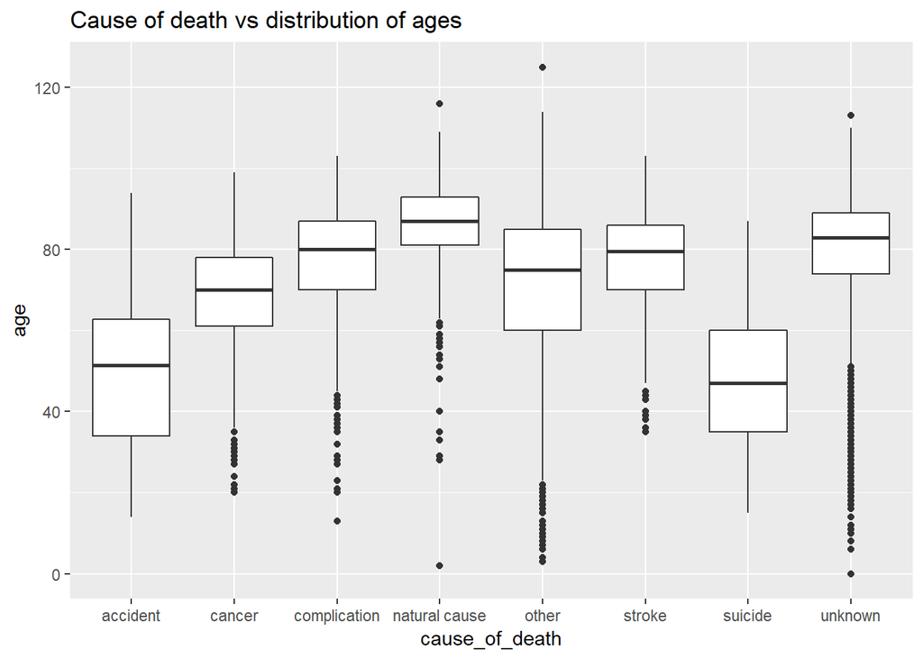

```r
#function to help determine the standardized cause of death
cause_adjuster <- function(celeb_deaths){
  sapply(celeb_deaths$cause_of_death, function(cause_of_death){
    #NA is considered unknown
    if (is.na(cause_of_death)){
     'unknown'
    } else if (grepl("cancer",cause_of_death,ignore.case = TRUE)){
     'cancer'
    } else if (grepl("complication",cause_of_death,ignore.case = TRUE)){
      'complication'
    } else if (grepl("complication", cause_of_death, ignore.case= TRUE)){
      'heart'
    } else if (grepl("stroke", cause_of_death, ignore.case = TRUE)){
      'stroke'
    } else if (grepl("suicide", cause_of_death, ignore.case = TRUE)){
      'suicide'
    #These involve anything that has to do with motorized vehicles
    } else if (grepl("crash", cause_of_death, ignore.case = TRUE) || grepl("accident",cause_of_death, ignore.case = TRUE)){
      'accident'
    } else if (grepl("natural", cause_of_death, ignore.case = TRUE)){
      'natural cause'
    #There are plenty of other less common causes of death present, so we just categorize them as other
    } else{
      'other'
    }
})
  }


celeb_deaths %>%
  mutate(cause_of_death = cause_adjuster(celeb_deaths)) %>%
  ggplot(mapping = aes(x=cause_of_death,y=age)) +
  geom_boxplot() + #boxplot helps show the distribution of the causes of death.
  ggtitle("Cause of death vs distribution of ages")
```

*Can you discover a linear regression model based on this?*

```r
#lm will generate the linear model of age with respect to cause of death.
death_lm <- lm(age~cause_of_death, data = celeb_deaths %>%
  mutate(cause_of_death = cause_adjuster(celeb_deaths)))
#we change the data so that it uses the categorized data set that we used for the last graph.
broom::tidy(death_lm)
```

```
## # A tibble: 8 x 5
##   term                        estimate std.error statistic   p.value
##   <chr>                          <dbl>     <dbl>     <dbl>     <dbl>
## 1 (Intercept)                    50.0      0.965     51.8  0.
## 2 cause_of_deathcancer           18.8      1.01      18.7  4.29e- 77
## 3 cause_of_deathcomplication     26.7      1.12      23.8  1.13e-123
## 4 cause_of_deathnatural cause    34.3      1.29      26.6  2.57e-153
## 5 cause_of_deathother            20.7      0.987     20.9  2.59e- 96
## 6 cause_of_deathstroke           27.2      1.34      20.2  5.46e- 90
## 7 cause_of_deathsuicide          -1.94     1.47      -1.32 1.87e-  1
## 8 cause_of_deathunknown          30.2      0.974     31.0  1.19e-206
```

Setting "Accident" to be our relative standard to compare the others against, it would appear that the only one that even gets us close to 27 would be death by suicide. Maybe adding a constraint of death_year would provide us with a more clear model.

```r
#Doing the same thing, but now we add the extra variable of the year
death_lm2 <- lm(age~death_year+cause_of_death, data = celeb_deaths %>%
  mutate(cause_of_death = cause_adjuster(celeb_deaths)))
broom::tidy(death_lm2)
```

```
## # A tibble: 9 x 5
##   term                        estimate std.error statistic   p.value
##   <chr>                          <dbl>     <dbl>     <dbl>     <dbl>
## 1 (Intercept)                  327.      74.6         4.38 1.19e-  5
## 2 death_year                    -0.138    0.0371     -3.71 2.07e-  4
## 3 cause_of_deathcancer          19.1      1.01       18.8  1.27e- 78
## 4 cause_of_deathcomplication    26.9      1.12       24.0  2.33e-125
## 5 cause_of_deathnatural cause   34.3      1.29       26.6  3.18e-153
## 6 cause_of_deathother           20.8      0.988      21.1  8.76e- 98
## 7 cause_of_deathstroke          27.3      1.34       20.3  5.84e- 91
## 8 cause_of_deathsuicide         -1.79     1.47       -1.22 2.23e-  1
## 9 cause_of_deathunknown         30.5      0.977      31.2  1.88e-209
```

While most causes of death still point upward, these model do tell us a few things. 1) From the first model, we see that, since the intercept is around 50 years old, and all causes of death have positive values, there is a decent chance that if if a person dies from anything besides a suicide or an accident, its a safe bet they were over 50 years old and have no chance of joining the 27 club. We also learn that, each year, the average age of celebrity deaths decreases by about .14, meaning that if two people both died from the same cause, but one a year after the other, the later one would probably have been about .14 years younger. Also, the cause of death correlation is relatively unchanged when year is taken into account.

## Conclusion

*Is the 27 Club really an anomoly?*

According to statistics by the CDC and information on the deaths of celebrities, there does seem to be some statistically significant amount of celebrities who die in the range of 25-30 years old.

*Is there some way to predict entrants based on the way they died?*

In all honesty, no, not really. However, there are ways to tell who is likely not an entrant, and who is more likely an entrant than others. More specifically, those who die in accidents or suicides are much more likely to be entrants than those dying of natural causes, strokes, or some sort of medical complication.